# Taylor Swift: Sentiment Analysis Across Albums

DSST389: Advanced Data Science

Author

Affiliation

Cooper Woods and Eric Markstein

University of Richmond

Published

March 16, 2025

## 1 Introduction

Taylor Swift has built a long and evolving career, consistently reinventing her musical style with each era. Her 6th studio album, *Reputation*, is known for its darker, more aggressive production sound. Unlike her other albums, Reputation is heavily influenced by themes of betrayal, defiance, and media scrutiny, and she embraces the villainous persona the media had projected onto her. By using **sentiment analysis** techniques, we take a quantitative approach to determine if Reputation stands apart as Taylor Swift’s most negative album.

## 2 Loading the Libraries and Dataset

```r
# Load necessary libraries
library(ggrepel)
library(tidytext)
library(textdata)
library(scales)

# Set theme and seed once
theme_set(theme_minimal())
```

```r
library(tidyverse)
set.seed(123)

songs <- read_tsv("../data/swift_corpus/cots-song-details.tsv") |>
  select(Album, Track, Title, FeaturedArtists, FromTheVault) |>
  rename(song_title = Title)

albums <- read_tsv("../data/swift_corpus/cots-album-details.tsv") |>
  select(Code, Title, SubTitle, Year) |>
  rename(album_title = Title)

lyrics <- read_tsv(
  file = "../data/swift_corpus/cots-lyric-details.tsv",
  col_names = FALSE
)

lyrics <- lyrics |>
  rename(metadata = 1, text = 2) |>
  separate(
    metadata,
    into = c("album_code", "track", "line", "part"),
    sep = ":",
    convert = TRUE
  )

lyrics <- lyrics |>
  left_join(albums, join_by(album_code == Code)) |>
  left_join(songs, join_by(album_code == Album, track == Track)) |>
  mutate(part = case_when(
    part == "V" ~ "Verse",
    part == "C" ~ "Chorus",
    part == "B" ~ "Bridge",
    part == "I" ~ "IntroOutro",
    part == "R" ~ "Refrain",
    TRUE ~ part
  )) |>
  rename(
    album_subtitle = SubTitle,
    year = Year,
    featured_artists = FeaturedArtists,
    from_the_vault = FromTheVault
  ) |>
  select(
    song_title, featured_artists, album_title, album_subtitle,
    track, from_the_vault, year, line, part, text
  )
```

## 3 Prepare the Data

To prepare the data for analysis, the lyrics are tokenized and the AFINN lexicon of English words sentiment rating is found for each word. The AFINN lexicon gives each word a rating between -5 for most negative and 5 for most positive.

```r
# tokenize words
tidy_lyrics <- lyrics |>
  unnest_tokens(input = text, output = word)
```

```r
# store the AFINN lexicon
afinn <- get_sentiments("afinn")

# creates a new table with sentiment values for each word
lyrics_afinn <- tidy_lyrics |>
  left_join(afinn, join_by(word)) |>
  mutate(sentiment_value = if_else(is.na(value), 0, value)) |>
  group_by(song_title, album_title, year) |>
  summarize(
    afinn_net = sum(sentiment_value),
    length = n()
  ) |>
  # normalize afinn by number of words in the song
  mutate(afinn_normalized = afinn_net / length) |>
  arrange(desc(afinn_normalized))
```

## 4 Data Analysis and Visualizations

### 4.1 Boxplot of Taylor Swift Albums vs. AFINN Normalized

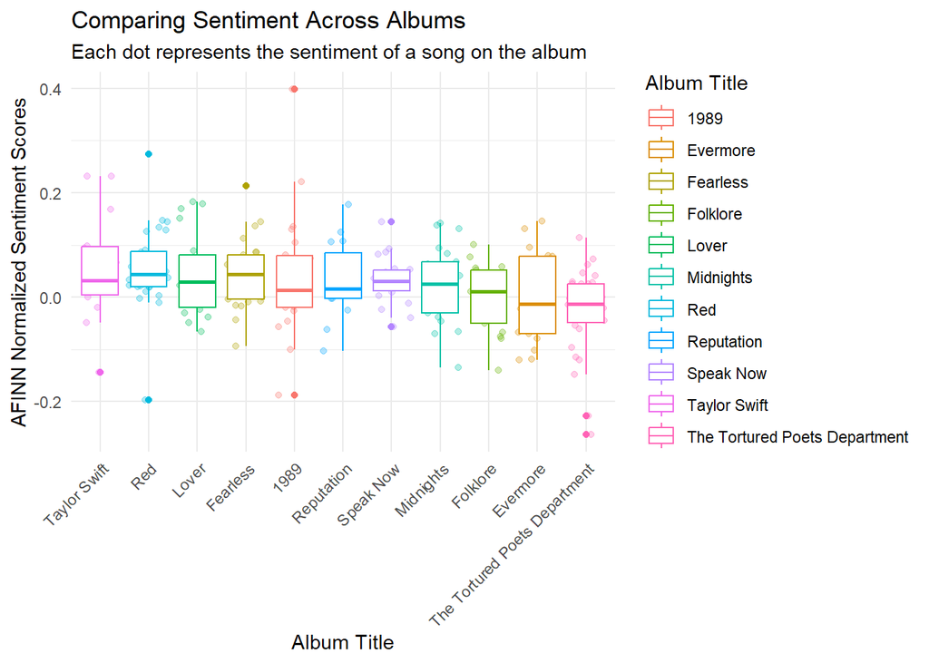

Figure 1: Comparing Sentiment Across Albums

```r
# creates a boxplot layered on top of a jitter plot
lyrics_afinn |>
  filter(album_title != "Other Songs") |>
  ggplot(aes(
    x = reorder(album_title, desc(afinn_normalized)),
    y = afinn_normalized,
    color = album_title
  )) +
  geom_jitter(alpha = 0.3) +
  geom_boxplot() +
  theme(axis.text.x = element_text(angle = 45, hjust = 1)) +
  labs(
    title = "Comparing Sentiment Across Albums",
    subtitle = "Each dot represents the sentiment of a song on the album",
    x = "Album Title",
    y = "AFINN Normalized Sentiment Scores",
    color = "Album Title"
  )
```

By plotting Taylor Swift’s albums by their associated AFINN Normalized Sentiment Score, we are able to see how Reputation compares to other albums. By examining the boxplots, along with individual song sentiment points, we find that **Reputation falls in the middle of the pack**.

### 4.2 Bar Chart Comparing Albums by Percentage of Positive, Negative, and Neutral Songs on Each Album

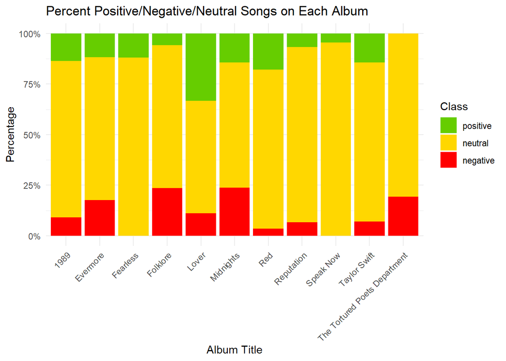

Figure 2: Comparing Sentiment Across Albums

```r
# bing categorizes words into binary positive or negative
bing <- get_sentiments("bing")

tidy_lyrics |>
  # keep just songs from albums
  filter(album_title != "Other Songs") |>
  group_by(song_title) |>
  mutate(song_length = n()) |>
  ungroup() |>
  left_join(bing, join_by(word)) |>
  drop_na(sentiment) |>
  group_by(song_title, song_length) |>
  count(sentiment) |>
  pivot_wider(
    names_from = sentiment,
    values_from = n,
    values_fill = 0
  ) |>
  ungroup() |>
  # add columns for net sentiment, normalized net sentiment
  # then determine sentiment class based on mean_bing +/- standard deviation
  mutate(
    net_sentiment = positive - negative,
    net_sentiment_normed = net_sentiment / song_length,
    mean_bing = mean(net_sentiment_normed, na.rm = TRUE),
    sd_bing = sd(net_sentiment_normed, na.rm = TRUE),
    bing_class = case_when(
      net_sentiment_normed > mean_bing + sd_bing ~ "positive",
      net_sentiment_normed < mean_bing - sd_bing ~ "negative",
      TRUE ~ "neutral"
    ),
    bing_class = fct_relevel(
      bing_class, "positive", "neutral", "negative"
    )
  ) |>
  inner_join(tidy_lyrics |> distinct(song_title, album_title),
             by = "song_title") |>
  # create bar plot
  ggplot(aes(x = album_title, fill = bing_class)) +
  geom_bar(position = "fill") +
  scale_y_continuous(labels = percent_format()) +
  scale_fill_manual(values = c("positive" = "chartreuse3",
                               "neutral" = "gold",
                               "negative" = "red")) +
  theme(axis.text.x = element_text(angle = 45, hjust = 1)) +
  labs(
    title = "Percent Positive/Negative/Neutral Songs on Each Album",
    x = "Album Title",
    y = "Percentage",
    fill = "Class"
  )
```

Therefore, if you are wanting to listen to one of Taylor Swift’s albums based on a certain vibe, consult this chart to find a blend of songs that best fits your mood.